# GLM Homework

Quentin D’Arcy

[output not shown]

[output not shown]

[output not shown]

[output not shown]

[output not shown]

[output not shown]

# 1) Comparing Means

## 1.1) LOad and plot the data

First we’ll load up the pinecone data and visualize it

```r
#For safety
setwd(here::here())

#Load in our brain data
pinecone <- read.csv("data/pinecone_data.csv")

#Visualize it
head(pinecone)
```

```
##         habitat conemass
## 1 island.absent      9.6
## 2 island.absent      9.4
## 3 island.absent      8.9
## 4 island.absent      8.8
## 5 island.absent      8.5
## 6 island.absent      8.2
```

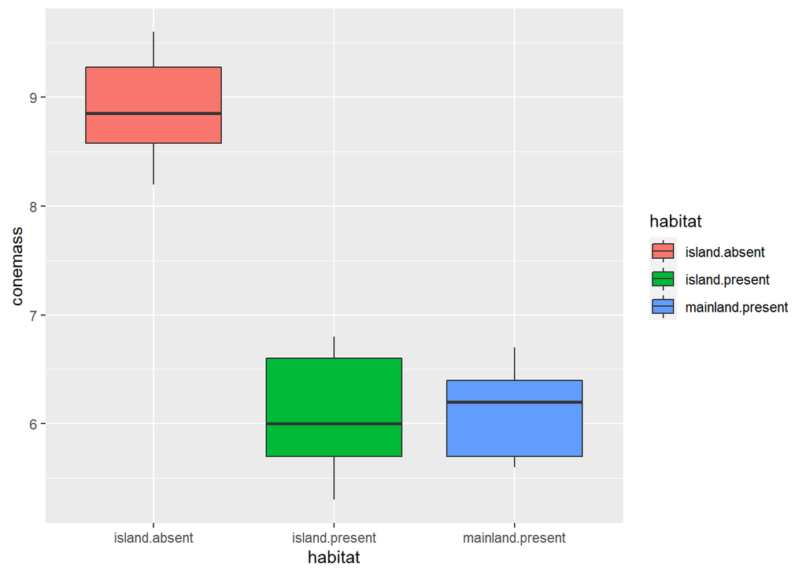

```r
#Create a plot of the data
pinecone_plot <- ggplot(data = pinecone,
                        mapping = aes(x = habitat,
                                      y = conemass,
                                      fill = habitat))
#Visualize it
pinecone_plot +
  geom_boxplot()
```

## 1.2) Fit a model using least squares and evaluate the relevant assumptions

So first I’ll fit the linear model and then I’ll check to make sure that our assumptions for linear regression hold

```r
#Create a model for this data using least squares
pinecone_lm <- lm(conemass ~ habitat,
               data = pinecone)
```

To check assumptions I’ll start with a residuals vs fitted plot

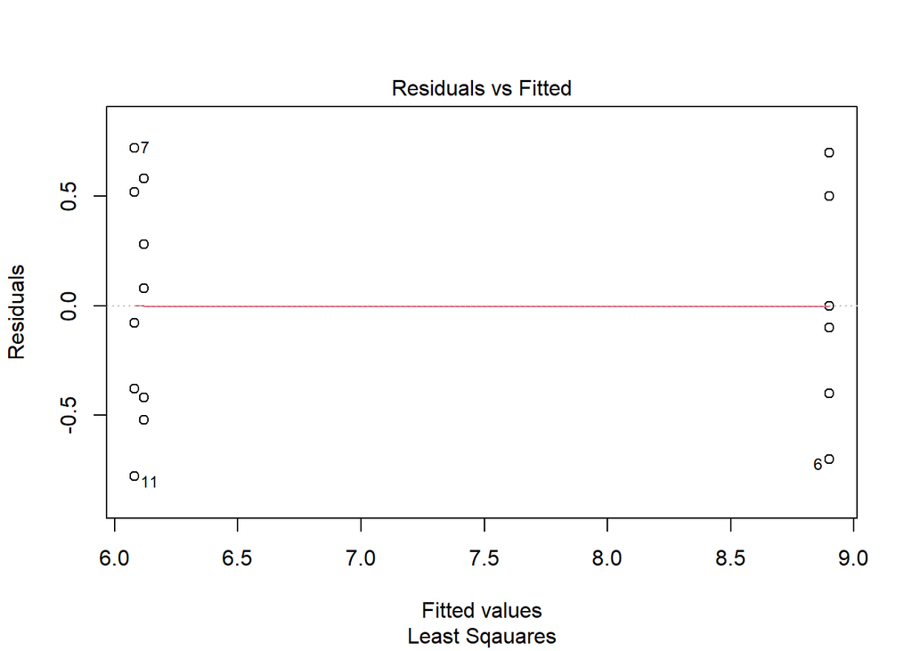

```r
#Plot the residuals vs the fitted data to see if there is a pattern
plot(pinecone_lm, which = 1,
     sub = "Least Sqauares")
```

For the least squares we can see a roughly horizontal, random distribution of points around the 0 line, suggesting a linear, homoskedastic relationship.

We can also plot them using the car library:

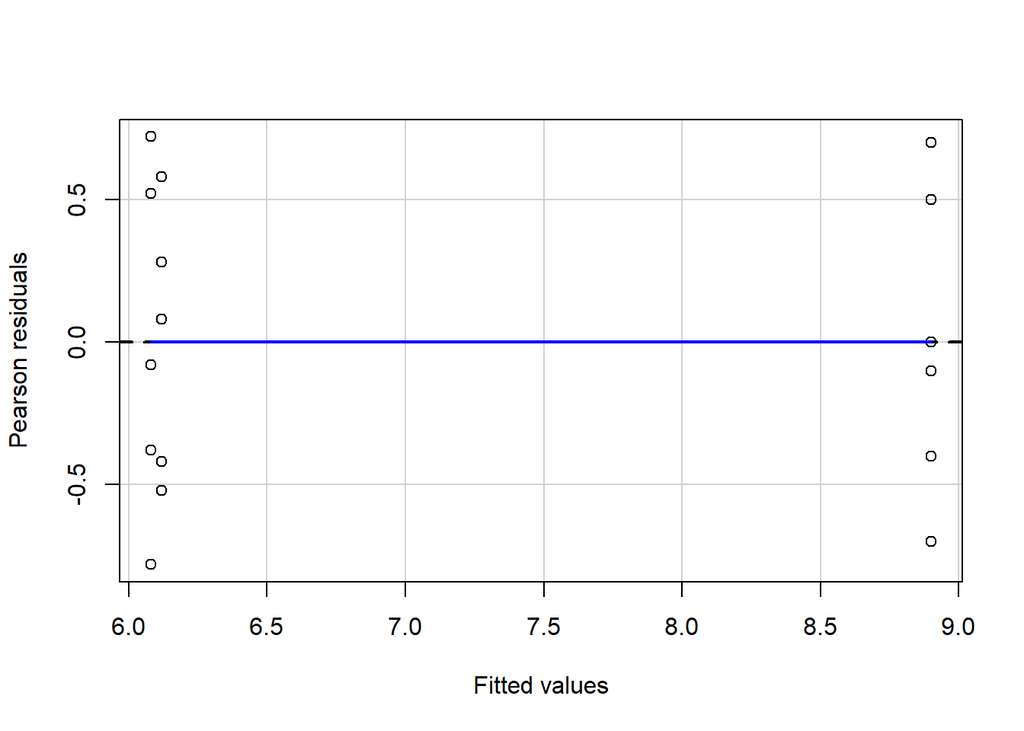

```r
residualPlots(pinecone_lm)
```

Next we’ll take a look at the QQ plot

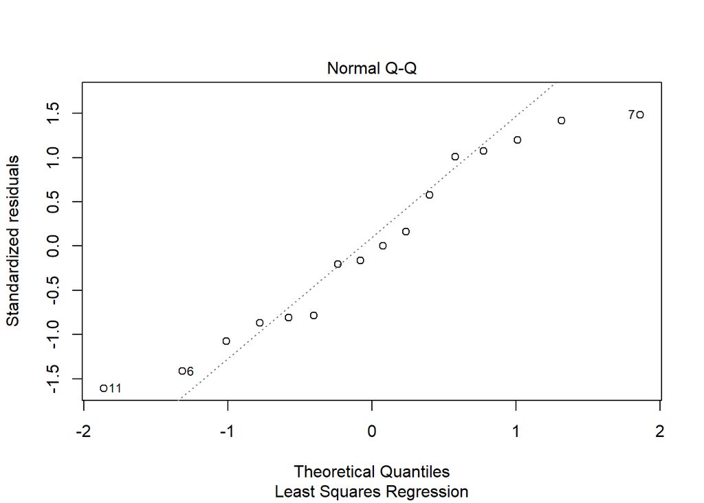

```r
#Plot the QQ data to see if there is a pattern
plot(pinecone_lm, which = 2,
     sub = "Least Squares Regression")
```

This isn’t perfect but does provide evidence that there is a normally distributed, linear relationship between X and Y (based on how close their quantiles fall in this QQ plot). I think that this plot supports the assumption of bivariate normal distribution but we need to keep checking.

The other assumption we need to confirm is that there isn’t a largely influential outlier skewing our model. First lets look at the cooks distance

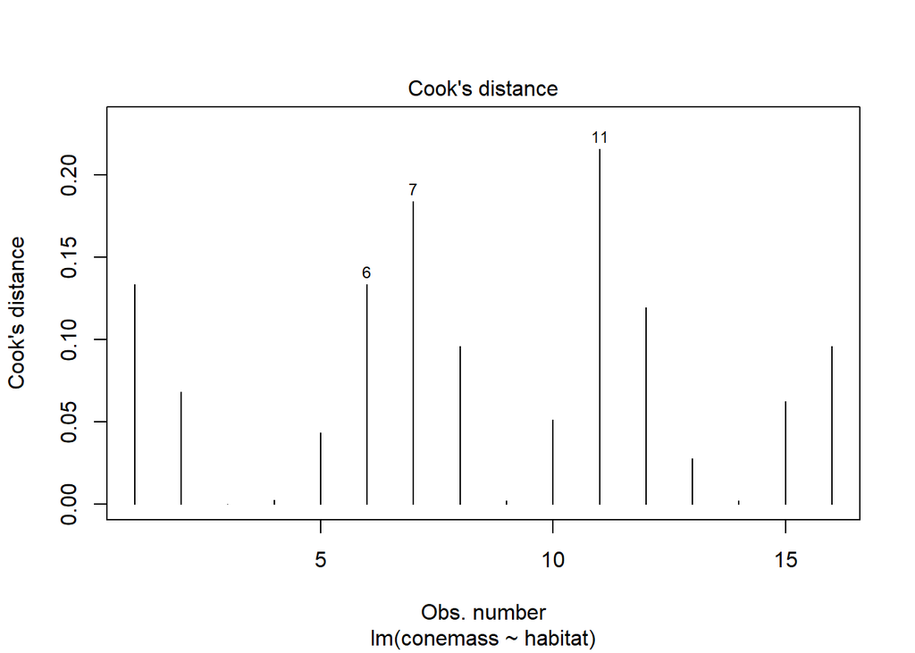

```r
plot(pinecone_lm, which = 4)
```

This looks pretty good, there’s no really strong outliers look at this but lets just make sure that the leverage graph lines up with this

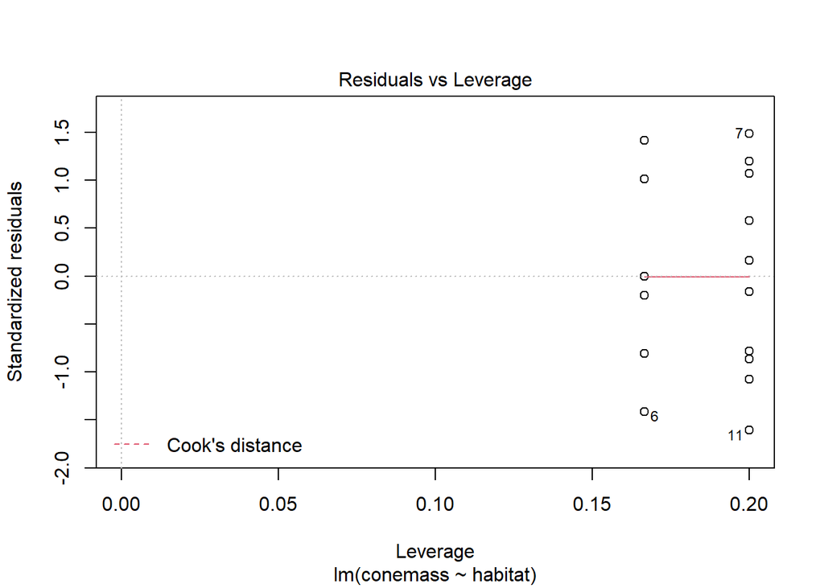

```r
#Plot the leverage of the data
plot(pinecone_lm, which = 5)
```

With this confirmation we can comfortably say that our assumptions required for our least squares regression model have been met.

## 1.3) How much variation is explained by your model?

In order to find this out we want to run an F-test on our data to see what proportion of the variation is explained by the model vs how much is explained by random noise

```r
#Find the r-squared value
summary(pinecone_lm)
```

```
##
## Call:
## lm(formula = conemass ~ habitat, data = pinecone)
##
## Residuals:
##    Min     1Q Median     3Q    Max
## -0.780 -0.405 -0.040  0.505  0.720
##
## Coefficients:
##                         Estimate Std. Error t value Pr(>|t|)
## (Intercept)               8.9000     0.2212  40.238 4.97e-15 ***
## habitatisland.present    -2.8200     0.3281  -8.596 1.01e-06 ***
## habitatmainland.present  -2.7800     0.3281  -8.474 1.18e-06 ***
## ---
## Signif. codes:  0 '***' 0.001 '**' 0.01 '*' 0.05 '.' 0.1 ' ' 1
##
## Residual standard error: 0.5418 on 13 degrees of freedom
## Multiple R-squared:  0.8851, Adjusted R-squared:  0.8675
## F-statistic: 50.09 on 2 and 13 DF,  p-value: 7.787e-07
```

## 1.3) Compare the means!

Now we can go through and compare the estimated means of our model to each treatment

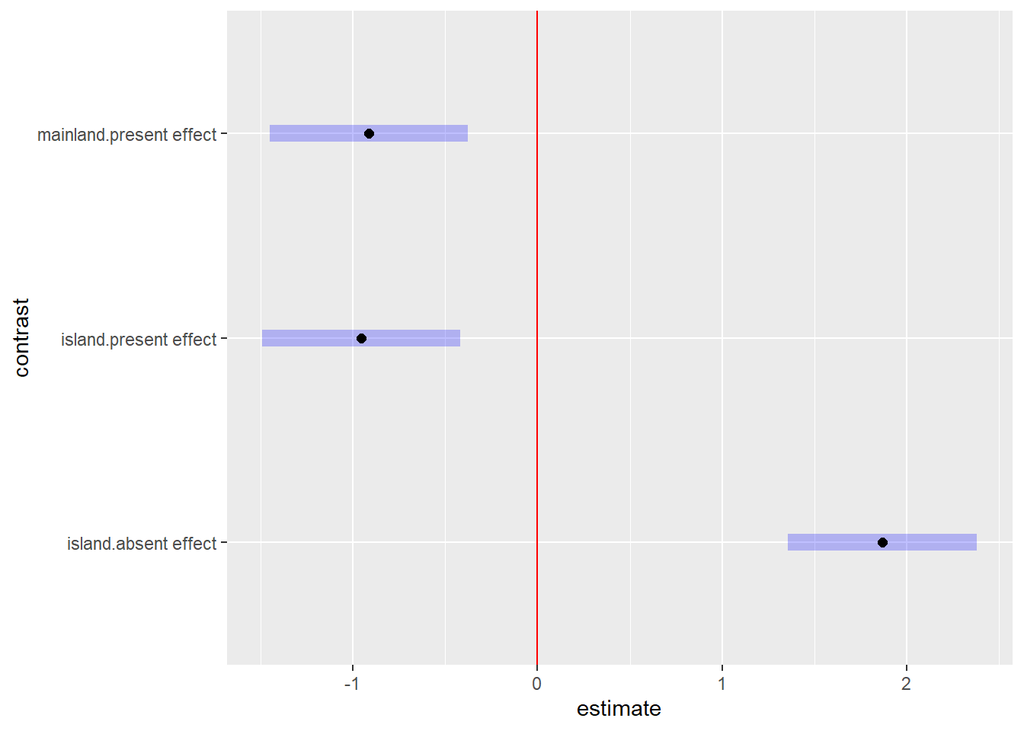

```r
#Grab the estimated means of our model
pinecone_em <- emmeans(pinecone_lm,
                         specs = ~ habitat,
                       method = "tukey",
                       adjust = "none")

#Visualize the contrast between the estimated means
contrast(pinecone_em) %>%
  plot() +
  geom_vline(xintercept = 0, color = "red")
```

```r
#Display our em means data
gt(as.tibble(contrast(pinecone_em))) %>%

  #Set up the tab header
  tab_header(
    title = "Estimated Mean Pinecone mass between habitats") %>%

  #Align it to the center
  opt_align_table_header(align = "center") %>%
  #Stripe the rows to make it more readable
  opt_row_striping(row_striping = TRUE)
```

Estimated Mean Pinecone mass between habitats

[output not shown]

Here we can see that the estimate of island.absent is significantly different than the two estimations for the mainland and island present habitats. In this cause I actually chose not to preform a p-value correction because the data that we are using is only n = 16, which is just not large enough a dataset to require correction. In this case I feel that any attempt at stat correction would not only be unnecessary but could potentially skew the results due to the low sample size.

#2) Comparing Means from Multiple Categories

Now we’ll use some data from a 2020 factorial study on the effect of predation on invertebrate levels in panels that are either caged or uncaged and placed on the side of a cinderblock or hanging on a piece of PVC attached to the block (giving predators less access).

## 2.1) Load and plot the data

Same as before, lets load up the data and take a look

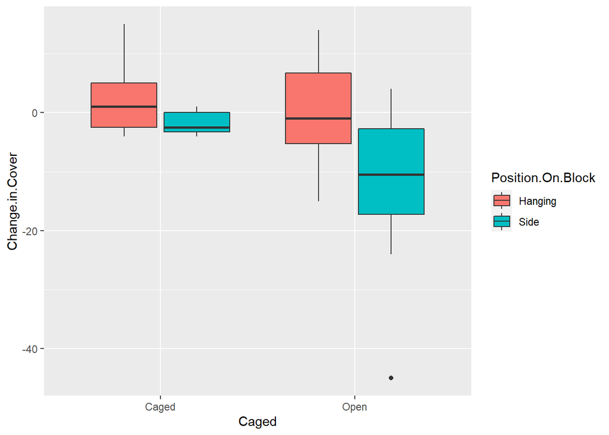

```r
#For safety
setwd(here::here())

#Load the data
coverage <- read.csv("data/transplant_data.csv")

#Plot it
#Create a plot of the data
coverage_plot <- ggplot(data = coverage,
                        mapping = aes(x = Caged,
                                      y = Change.in.Cover,
                                      fill = Position.On.Block))
#Visualize it
coverage_plot +
  geom_boxplot()
```

## 2.2) Fit a model using likelihood and evaluate all relevant assumptions

So this time instead of using the least squares regression model we’ll be using the likelihood regression model

```r
#Likelihood regression model
coverage_glm <- glm(Change.in.Cover ~ Caged*Position.On.Block,
                    data = coverage,
                    family = gaussian(link = "identity"))
```

Now we can test this similarly to the previous model, except this time we’ll also have to verify that our model profile is well behaved

First the usual suspects

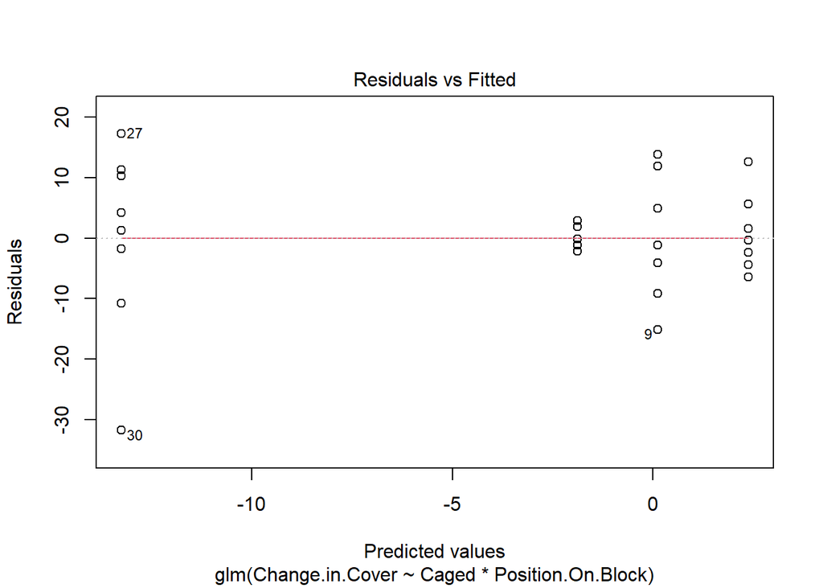

```r
#Residuals vs Fitted
plot(coverage_glm, which = 1)
```

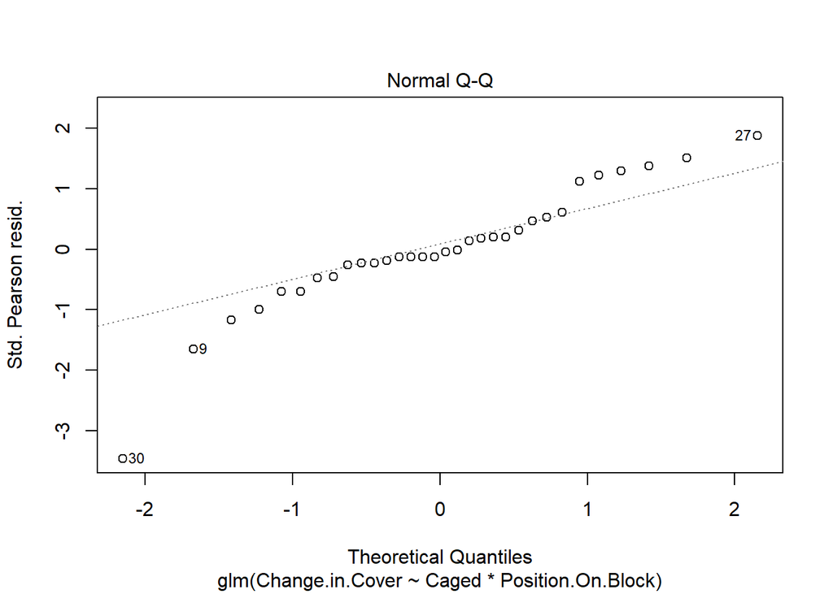

```r
#QQ
plot(coverage_glm, which = 2)
```

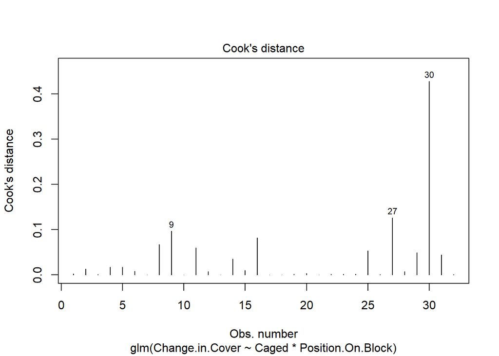

```r
#Cook's
plot(coverage_glm, which = 4)
```

We can see that this data doesn’t meet the required assumptions for a linear regression.

First the Residuals vs Fitted plot looks OK, maybe a leaning a little bit negative for the last group and a little positive for the first group.

Next, and probably clearest, the qq plot doesn’t look like a nice, straight line. Instead we can see the data only resembles linearity in the middle around 0. Towards the ends it starts to diverge pretty significantly around 1,-1

Finally we can see a rather large outlier in the Cook’s distance at point 30.

To test the normality of this model we can also run a Shapiro-Wilks normality test on our residuals. This is an NHST where the null hypothesis is that our residuals are normally distributed (assuming an alpha of .05)

```r
#Run a Shapiro-Wilks test on the residuals
shapiro.test(residuals(coverage_glm))
```

```
##
##  Shapiro-Wilk normality test
##
## data:  residuals(coverage_glm)
## W = 0.91664, p-value = 0.01687
```

Here we can see that our p-value is low enough to reject the null that our residuals are normally distributed.

We can also assess our model’s profile to see if those are well behaved. If they aren’t it provides more support for us chucking this model out. However, if they are well behaved it suggests that this model is at least internally valid.

```r
library(profileModel)
prof <- profileModel(coverage_glm,
                     objective = "ordinaryDeviance")
```

```
## Profiling for parameter (Intercept) ... Done
## Profiling for parameter CagedOpen ... Done
## Profiling for parameter Position.On.BlockSide ... Done
## Profiling for parameter CagedOpen:Position.On.BlockSide ... Done
```

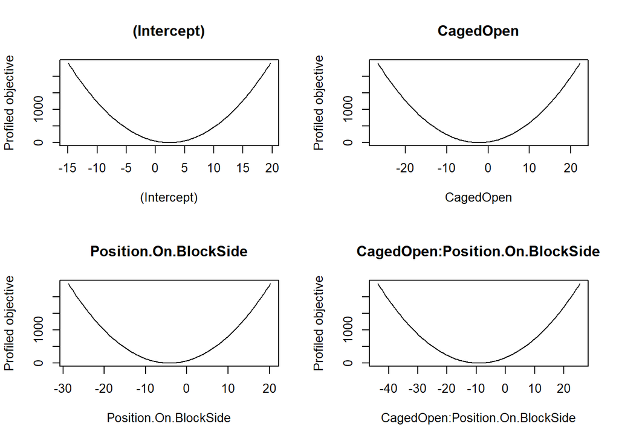

```r
plot(prof)
```

The curve looks ok but we can check linearity by checking the tau chart:

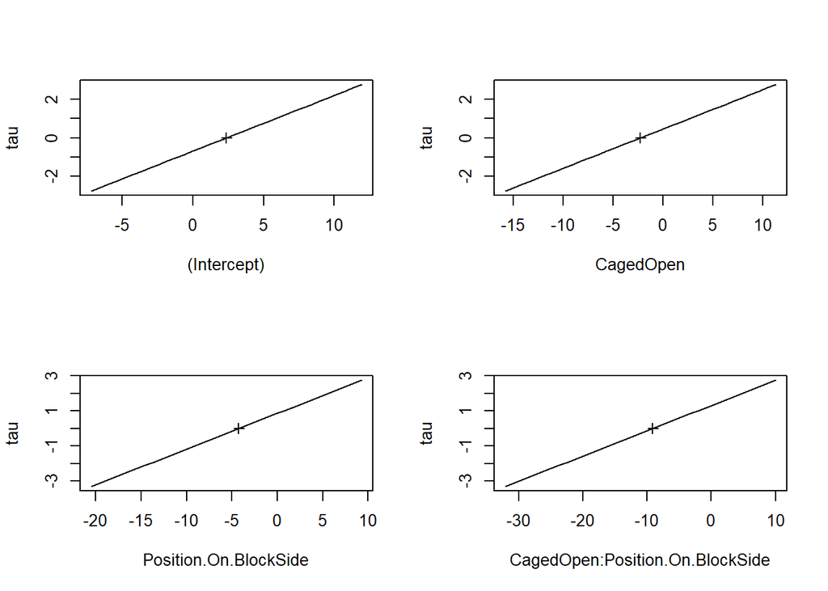

```r
library(MASS)
#Ensure that we have a linear relationship in our model
like_mass <- profile(coverage_glm)
plot(like_mass)
```

So it looks like the model passes the profile check, however because of all the previous assumption violations any inferences we derive from this model are going to be inaccurate.

## 2.3) Fix our model

Now that we know that our original model isn’t passing our necessary assumptions for linear regression we need to alter it to make it work. We’ll try to do this three ways to get around the strangeness of % change data

### a) Covariate with intial cover

By adding Initial Cover as a covariate we can normalize a baseline for our % data, hopefully removing the outlier(s).

```r
#Likelihood regression model
covariate_glm <- glm(Change.in.Cover ~ Caged*Position.On.Block+Initial.Cover,
                    data = coverage,
                    family = gaussian(link = "identity"))
```

Now we can take another look at the assumptions

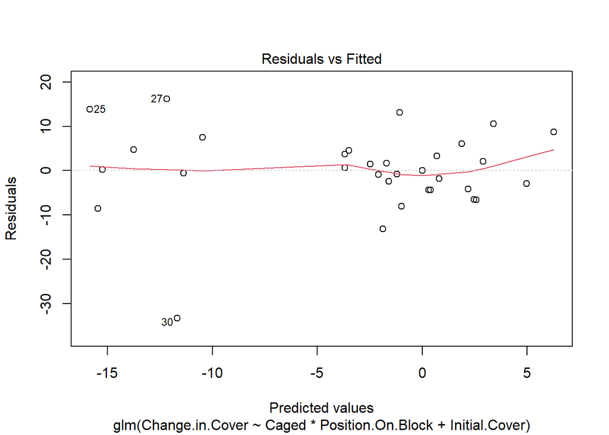

```r
#Residuals vs Fitted
plot(covariate_glm, which = 1)
```

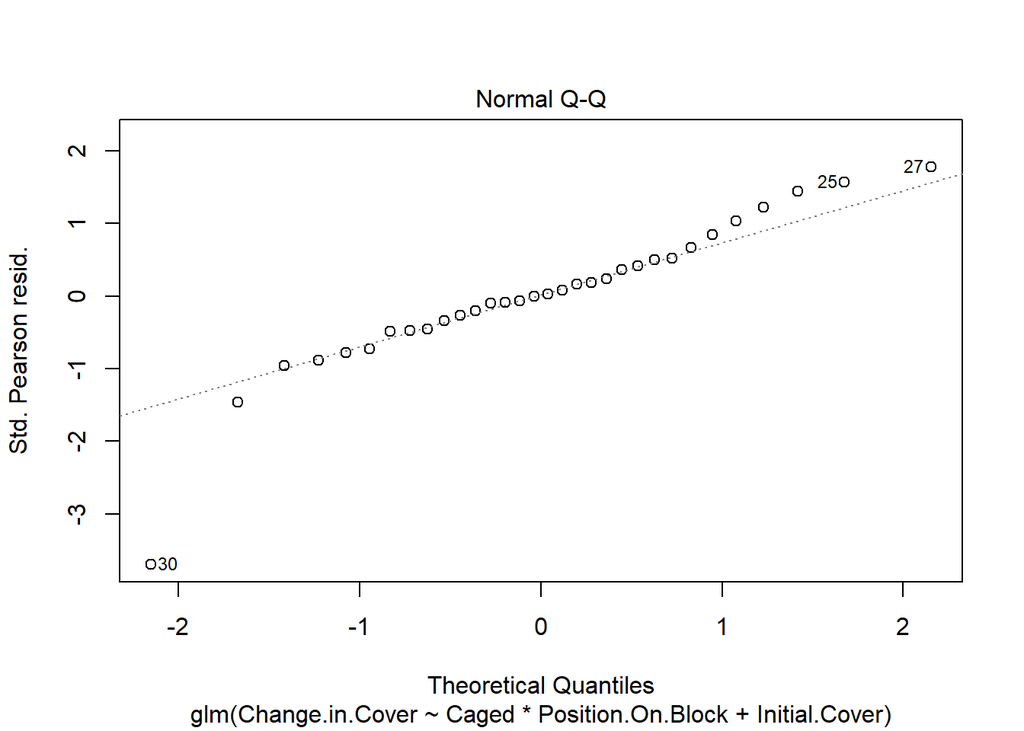

```r
#QQ
plot(covariate_glm, which = 2)
```

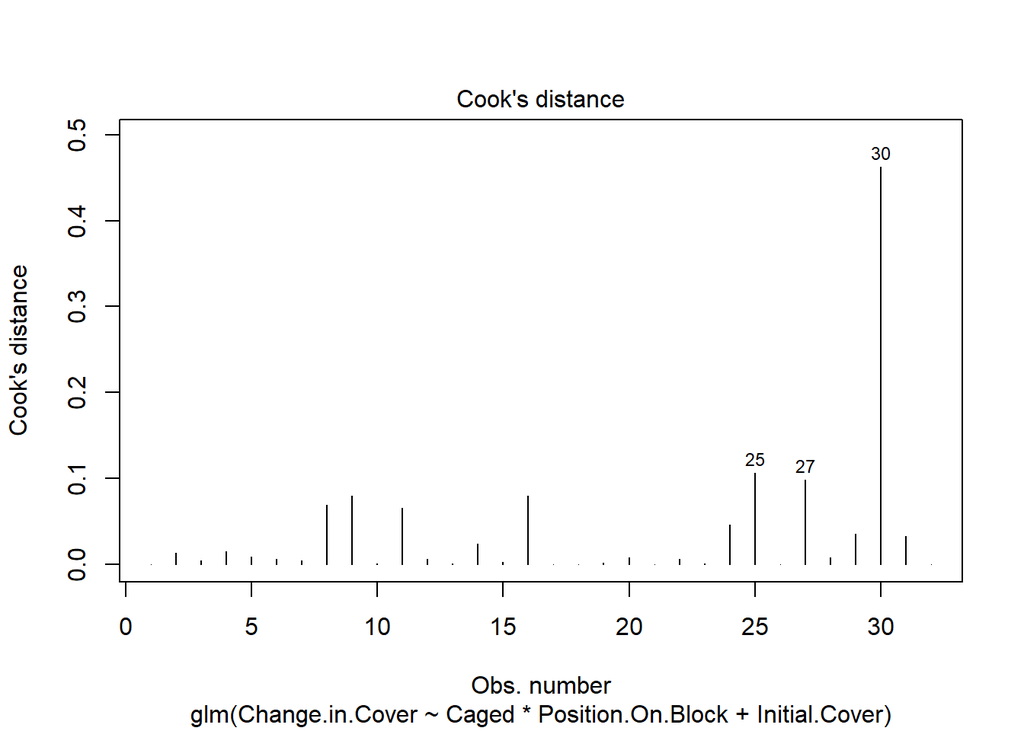

```r
#Cook's
plot(covariate_glm, which = 4)
```

```r
#Shapiro Test
shapiro.test(residuals(covariate_glm))
```

```
##
##  Shapiro-Wilk normality test
##
## data:  residuals(covariate_glm)
## W = 0.90022, p-value = 0.006273
```

Lets take a look at our assumptions:

- So we’ve done a good job here linearizing the QQ plot but we are still seeing data point 30 as a significant outlier in the Cook’s distance plot.
- The residuals vs fitted plot looks pretty good but it does seem to skew just a little positive.
- Finally the Shapiro test came out with a p-value much lower than .05, suggesting we can reject the null hypothesis of residual normal distribution

Overall this honestly isn’t a bad fix. I do, however, have a sneaking suspicion that the Shapiro test is a skewed towards the low p-value we see here because of that one data point, point 30. Just out of curiosity….

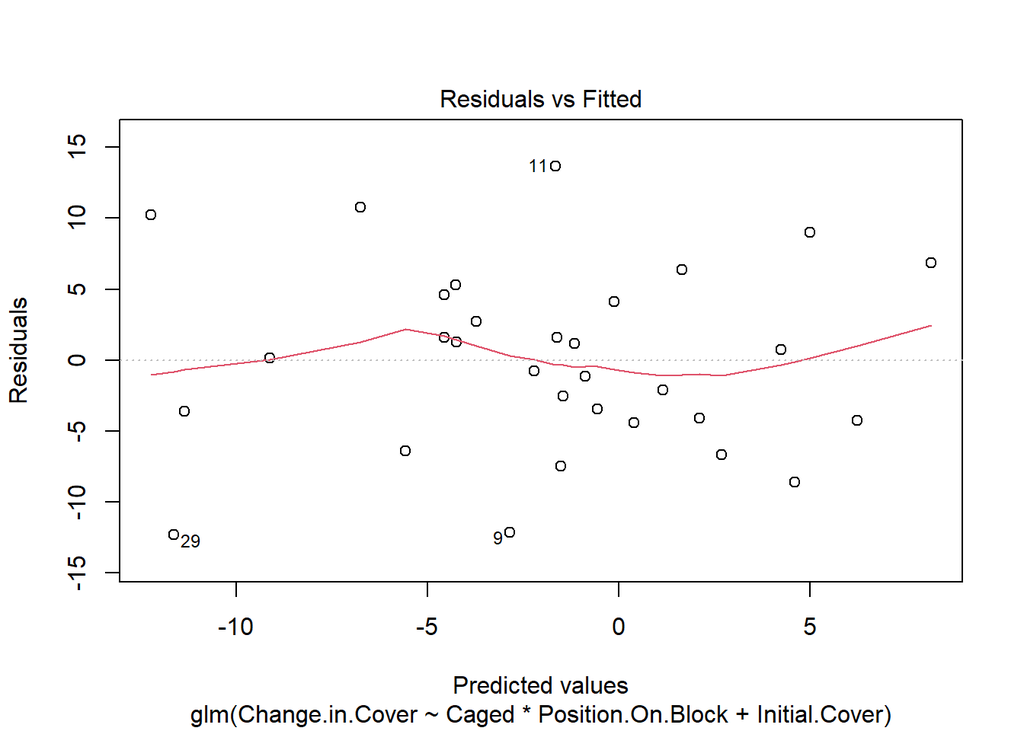

```r
#Remove point 30 from the data set and test assumptions again
minus_30 <- coverage[-c(30),]

#Likelihood regression model
minus_30_glm <- glm(Change.in.Cover ~ Caged*Position.On.Block+Initial.Cover,
                    data = minus_30,
                    family = gaussian(link = "identity"))

#Residuals vs Fitted
plot(minus_30_glm, which = 1)
```

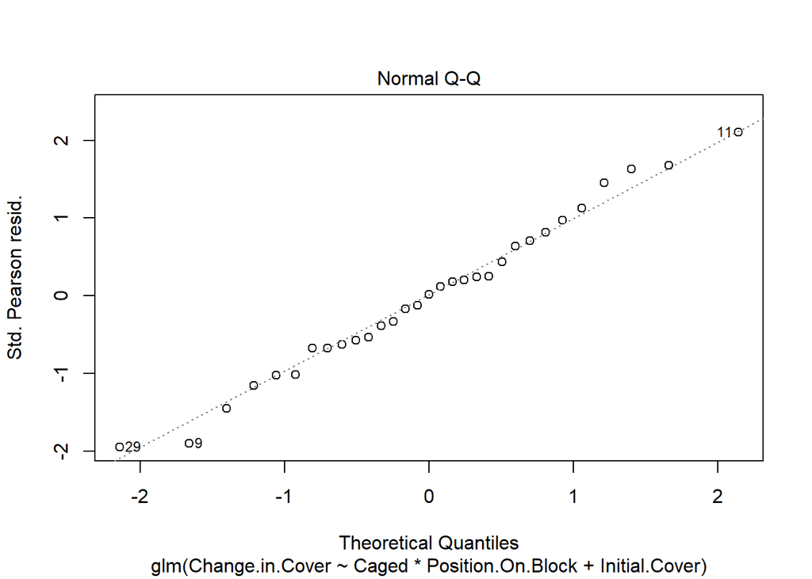

```r
#QQ
plot(minus_30_glm, which = 2)
```

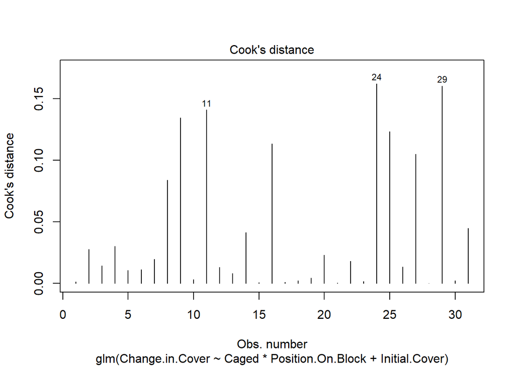

```r
#Cook's
plot(minus_30_glm, which = 4)
```

```r
#Shapiro Test
shapiro.test(residuals(minus_30_glm))
```

```
##
##  Shapiro-Wilk normality test
##
## data:  residuals(minus_30_glm)
## W = 0.98669, p-value = 0.9584
```

As suspected, the assumption check passes with flying colors with this model minus the apparent outlier.

That being said I want to be really careful removing outliers from a dataset this small. How do I know that this is actually an outlier and not a segment of the population that I just sampled poorly??

I think that I might run in to some external validity issues by forcing the data to meet my assumptions this perfectly.

In this case I’d rather try fitting some other models that may be able to better incorporate ALL the data, not just MOST of the data.

### b) Divide the % cover by the initial cover

By dividing the % cover by the initial cover we can speak in terms of relative changes

```r
#Likelihood regression model
division_glm <- glm(Change.in.Cover/Initial.Cover ~ Caged*Position.On.Block,
                    data = coverage,
                    family = gaussian(link = "identity"))
```

Now we can take another look at the assumptions

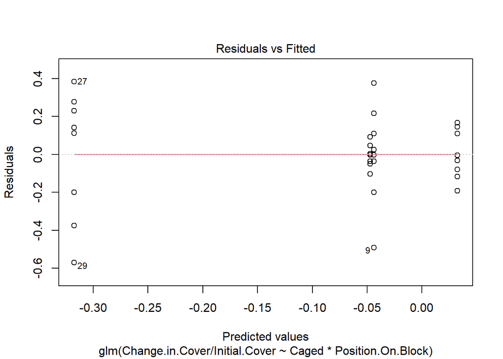

```r
#Residuals vs Fitted
plot(division_glm, which = 1)
```

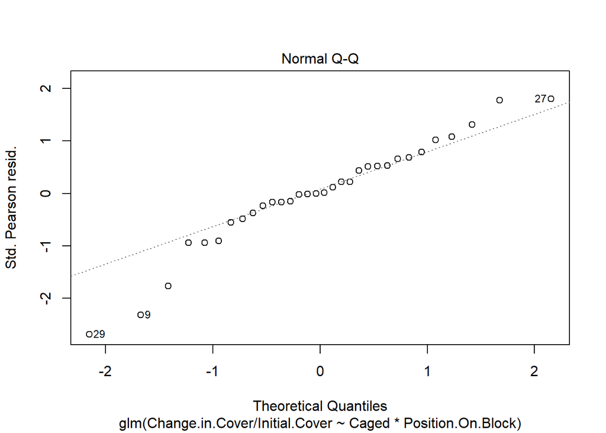

```r
#QQ
plot(division_glm, which = 2)
```

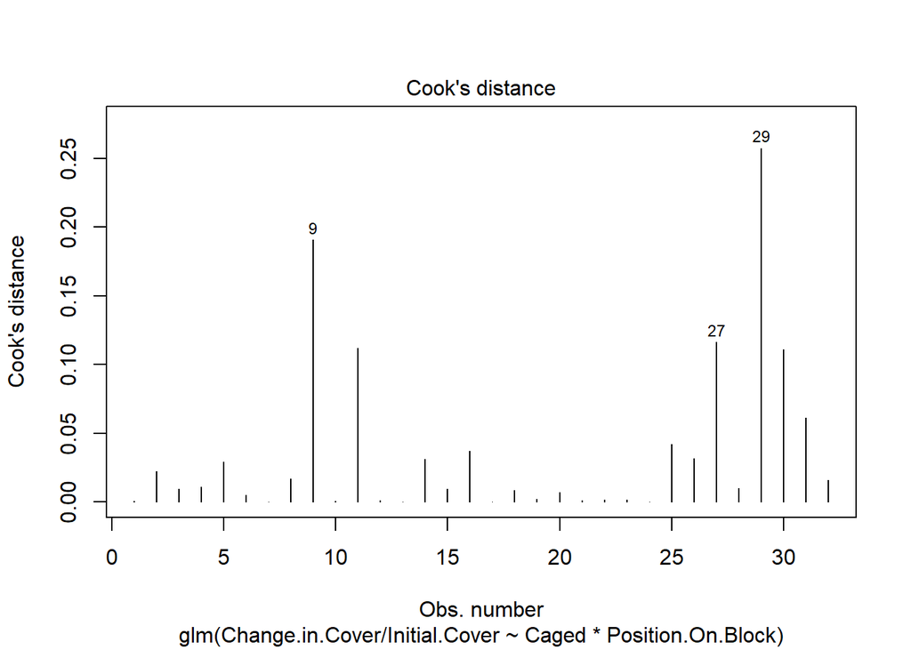

```r
#Cook's
plot(division_glm, which = 4)
```

```r
#Shapiro Test
shapiro.test(residuals(division_glm))
```

```
##
##  Shapiro-Wilk normality test
##
## data:  residuals(division_glm)
## W = 0.95055, p-value = 0.1494
```

Lets take a look at our assumptions:

- Our residual vs fitted plot looks great here, nice and evenly distributed around that 0 line
- The QQ plot doesn’t look quite as nice as it did in the covariate model but I would say it looks better than the original model.
- The Cook’s distance plot is the most improved here, incorporating that problem child point much better than the covariate model.
- The Shapiro test for this one came out validating the null hypothesis of normally distributed residuals, something the first model wasn’t able to do. This is likely due to the lack of strong outliers.

This is another pretty solid fix. Unlike the covariate fix our QQ plot is pretty wacky, which is a problem and may disqualify the model from passing assumptions. However, the other plots and the Shapiro test all suggest that the data is homoscedastic with no major outliers.

### c) Log the cover change and use that as our response variable

By log transforming the percent change we can (hopefully) linearize it and pass linear regression assumptions

```r
#Create our response variable
coverage <- coverage %>%
  rowwise() %>%
  mutate(percent_change = logit(Initial.Cover) - logit(Final.Cover))

#Likelihood regression model
log_glm <- glm(percent_change ~ Caged*Position.On.Block,
                    data = coverage,
                    family = gaussian(link = "identity"))
```

Now we can take another look at the assumptions

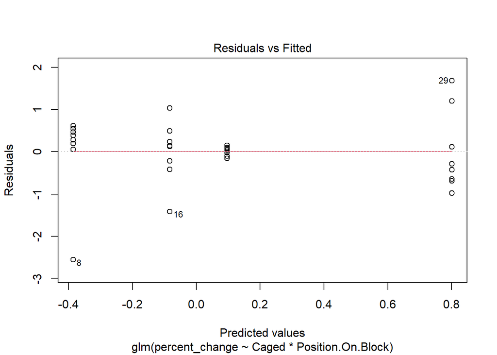

```r
#Residuals vs Fitted
plot(log_glm, which = 1)
```

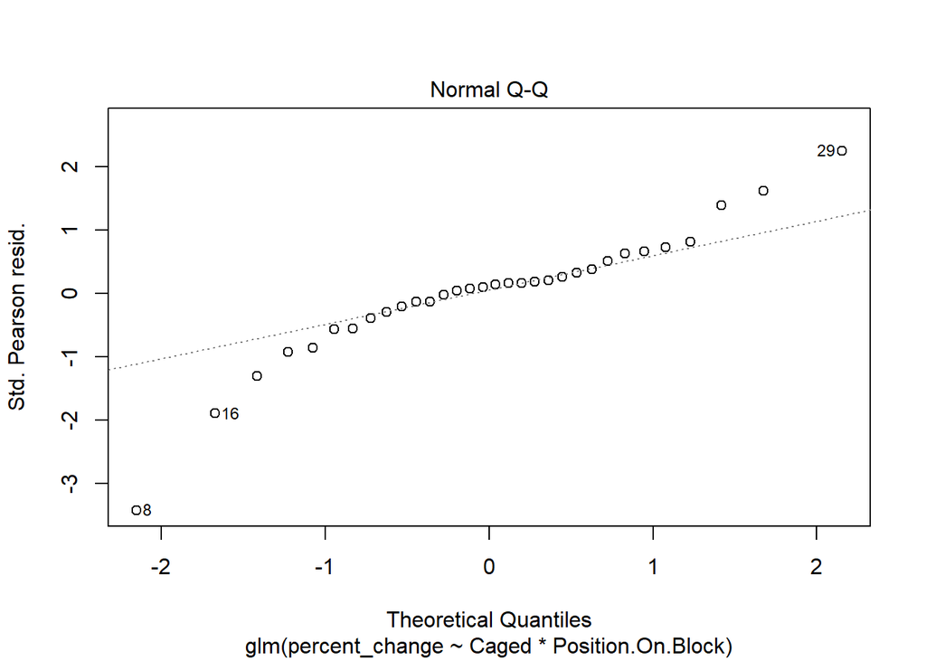

```r
#QQ
plot(log_glm, which = 2)
```

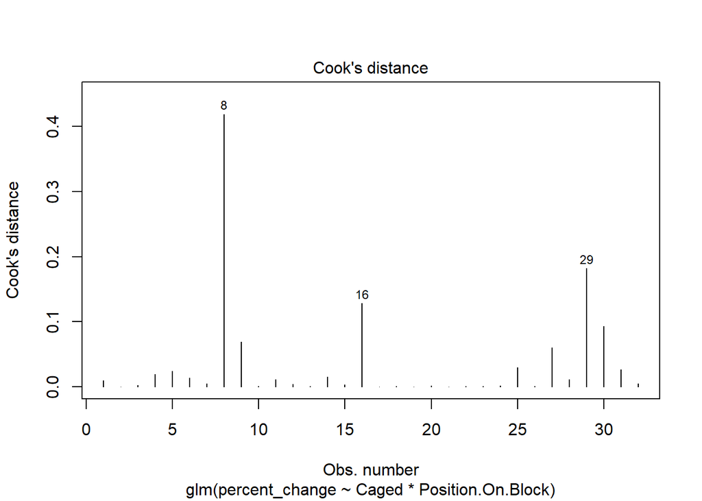

```r
#Cook's
plot(log_glm, which = 4)
```

```r
#Shapiro Test
shapiro.test(residuals(log_glm))
```

```
##
##  Shapiro-Wilk normality test
##
## data:  residuals(log_glm)
## W = 0.9097, p-value = 0.01104
```

Here we can see we have the same kind of problems as the original:

Overall I think that the best solution to this would be the first covariate model. Even though it was a problem with a single outlier it does fit the majority of the data very well. The QQ plot for the covariate model shows the most linearity and all the other points in the model don’t show undue leverage.

Additionally, as demonstrated, removing the large outlier makes this model line up pretty much perfectly with the data. It would be nice to have more data or to maybe re-sample to see if the data point was indeed an outlier or if our original experiment suffered from sampling error.

## 2.4 Using NHST with an alpha of .08, what does this fit model tell us about whether predation matters in this system?

```r
#Run an anova
Anova(covariate_glm)
```

```
## Analysis of Deviance Table (Type II tests)
##
## Response: Change.in.Cover
##                         LR Chisq Df Pr(>Chisq)
## Caged                     4.5133  1    0.03363 *
## Position.On.Block         6.1491  1    0.01315 *
## Initial.Cover             1.3319  1    0.24847
## Caged:Position.On.Block   2.0384  1    0.15337
## ---
## Signif. codes:  0 '***' 0.001 '**' 0.01 '*' 0.05 '.' 0.1 ' ' 1
```

Assuming an alpha of .08 there’s a couple of different things we can say based on our ANOVA results:

- Whether or not a panel is caged has a significant effect on predation and the subsequent change in invertebrate cover of that panel
- The position of the panels on the block (either on the side or hanging) has a significant effect on predation and the subsequent change in invertebrate cover of those panels.
- The is no significant interaction between being the caged treatment and the position treatment (i.e., being caged and hanging is not significantly different than being caged or hanging)

# 3 Rat Castes, mass, and their energy levels

## 3.1 Load the data and check assumptions

We’ll do a Bayesian model this time (I will assume interaction in this model)

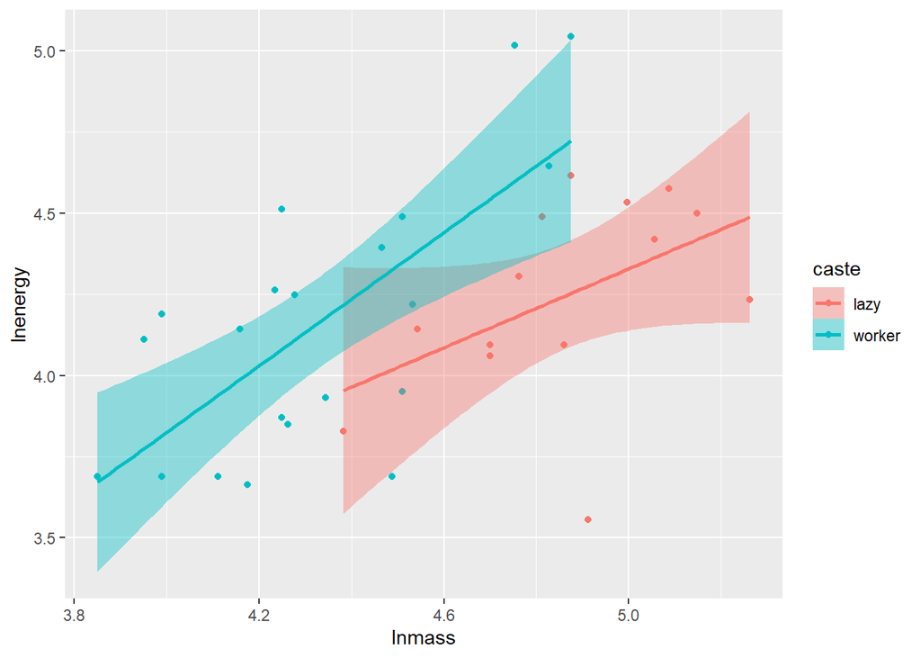

```r
#For safety
setwd(here::here())

#Load the data
rats <- read.csv("data/rat_data.csv")

#Plot it
#Create a plot of the data
rat_plot <- ggplot(data = rats,
                   mapping = aes(x = lnmass,
                                 y = lnenergy,
                                 fill = caste,
                                 color = caste))
#Visualize it
rat_plot +
  geom_point()+
  stat_smooth(method = "lm")
```

```r
#Create the BRM
rat_brm <- brm(lnenergy ~ lnmass*caste,
               data = rats,
               family = gaussian(link = "identity"),
               chains = 2)
```

Now that we have our model we can check out assumptions

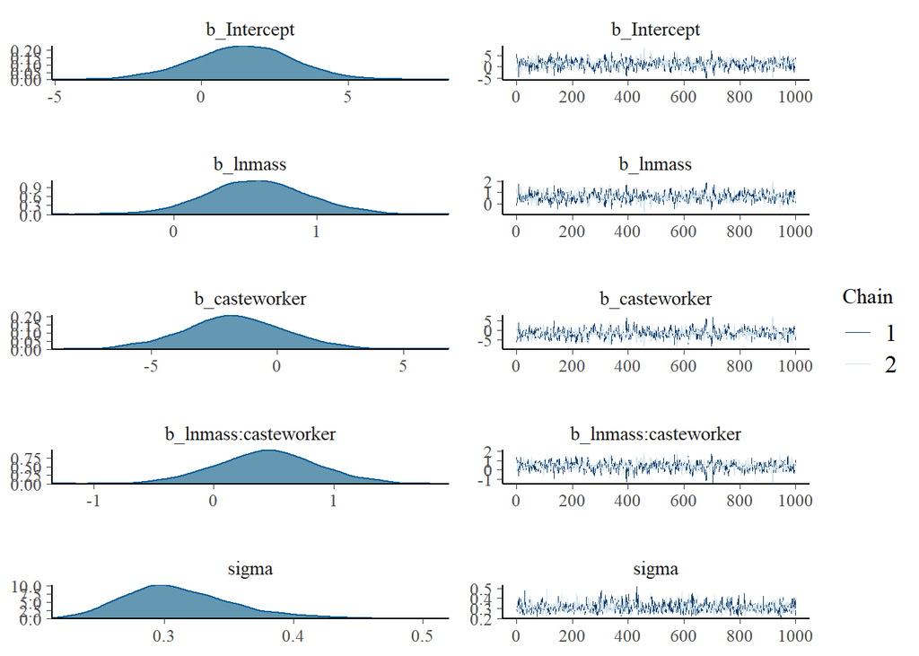

```r
#Plot the posteriors
plot(rat_brm)
```

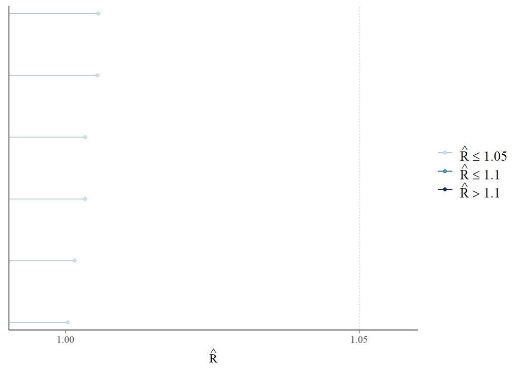

```r
#Check the rhat scores
rhat(rat_brm) %>% mcmc_rhat()
```

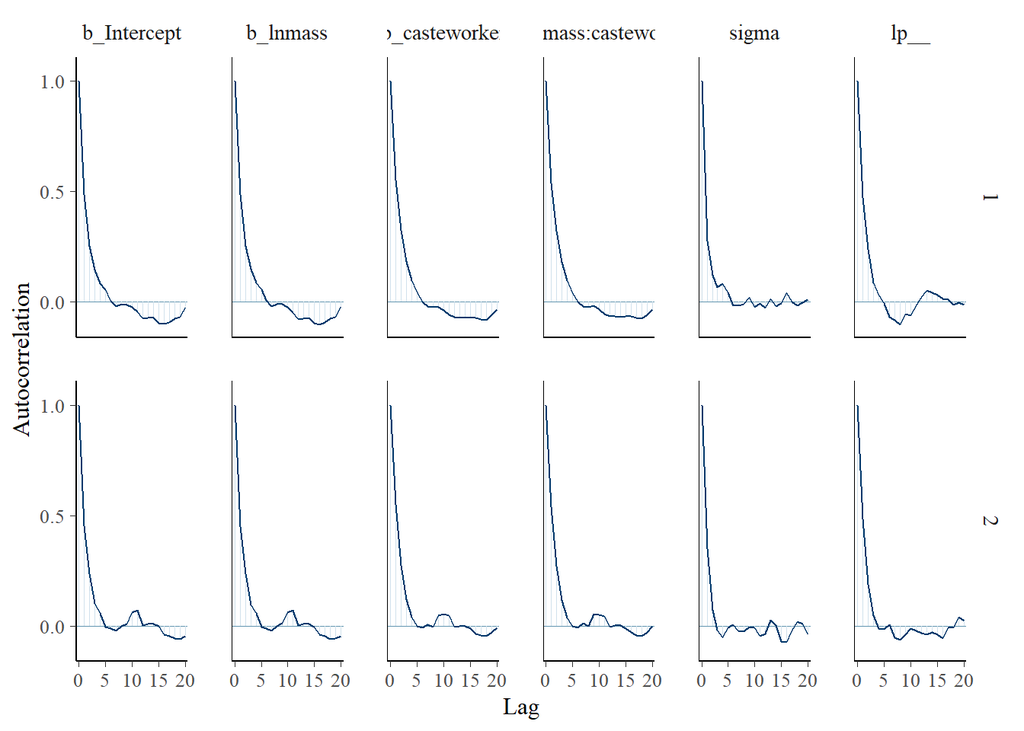

```r
#Make sure we don't show autocorrelation
mcmc_acf(rat_brm)
```

```r
#visualize our fit
pp_check(rat_brm, "dens_overlay")
```

```
## Using 10 posterior samples for ppc type 'dens_overlay' by default.
```

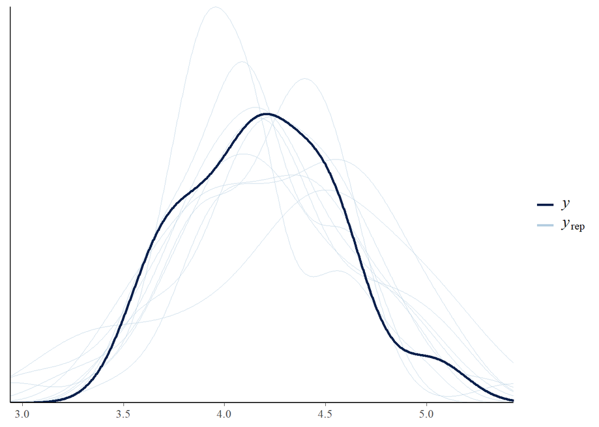

All of these looks pretty good!

Our posteriors have a nice shape and our chains converge, our rhat is close to 1 (another indicator of convergence), we see all our ACF graphs drop to 0 nicely so there’s no auto-correlation, and the fit looks like it is pulling in the prominent features of the data.

## 3.2 Use LOO CV to decide if there is an interaction of not

We will create another model that DOESN’T assume interaction and we’ll compare the two

```r
#Create the new non-interaction model
norat_brm <- brm(lnenergy ~ lnmass+caste,
               data = rats,
               family = gaussian(link = "identity"),
               chains = 2)
```

```
## recompiling to avoid crashing R session
```

```r
#Create a LOO object for each model
rat_loo <- loo(rat_brm)
norat_loo <- loo(norat_brm)

#compare the two and see which most closely resembles the data
loo_compare(rat_loo, norat_loo)
```

```
##           elpd_diff se_diff
## norat_brm  0.0       0.0
## rat_brm   -0.4       0.8
```

## 3.3 Compare the two castes energy expendeture at the meanlevel of log mass

```r
#Get the estimated means for each group in our model
emmeans(norat_brm, ~caste, method = "tukey")
```

```
##  caste  emmean lower.HPD upper.HPD
##  lazy     3.96      3.77      4.16
##  worker   4.35      4.19      4.50
##
## Point estimate displayed: median
## HPD interval probability: 0.95
```

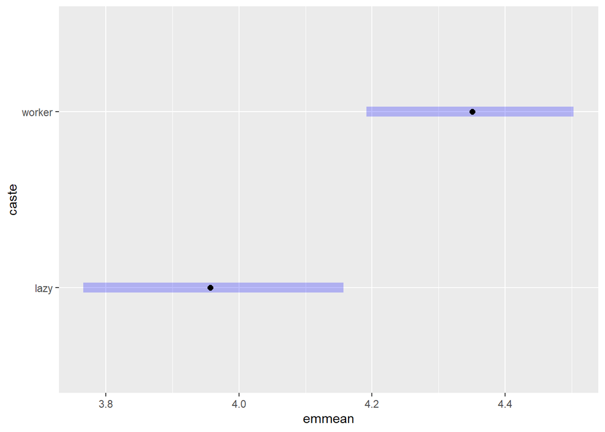

```r
#Compare the difference between the groups visually
emmeans(norat_brm, ~caste) %>%
  plot(contrast(method = "tukey"))
```

We can see that there is definitely a difference between the two castes’ energy expenditure at their mean lnlmass with the worker’s energy expenditure being higher than the lazy rats energy expenditure.

In this case we could say that this model estimates that the worker caste’s energy expenditure at the mean logmass is significantly higher than that of the lazy caste’s energy expenditure at the mean logmass.

## 3.4) Plot the fit model

Now we can visualize the model

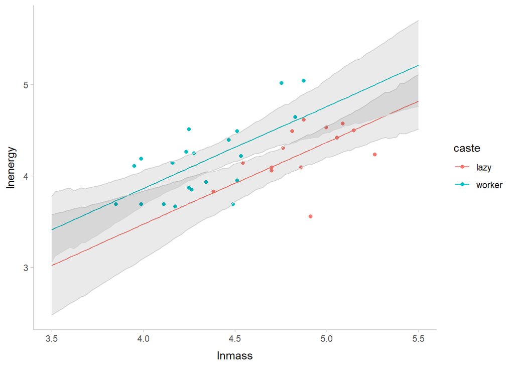

```r
#use emmeans to generate our predictions with a 100 lnmass sequence
rats_newfit <- emmeans(norat_brm, specs = ~ caste + lnmass,
                        at = list(lnmass = seq(3.5,5.5, length.out = 100))) %>%

  #change it to a tibble
  as_tibble() %>%

  #create an lnenergy column to plot the emmeans
  mutate(lnenergy = emmean)

#plot our 1) data, 2) fit lines, 3) our CI's
ggplot(data= rats,
       aes(x = lnmass,
           y = lnenergy,
           color= caste)) +
  geom_point() +
  geom_line(data = rats_newfit) +
  geom_ribbon(data= rats_newfit,
              aes(ymin= lower.HPD, ymax= upper.HPD, group=caste),
              alpha = 0.1, color = "lightgrey")+
  theme_tidybayes()
```